# nkelley_FinalHomeworkCode_03

# Part Three

Use {ggplot} to make scatterplots of height and weight in relation to age. Do these variables seem to be related? In what way?

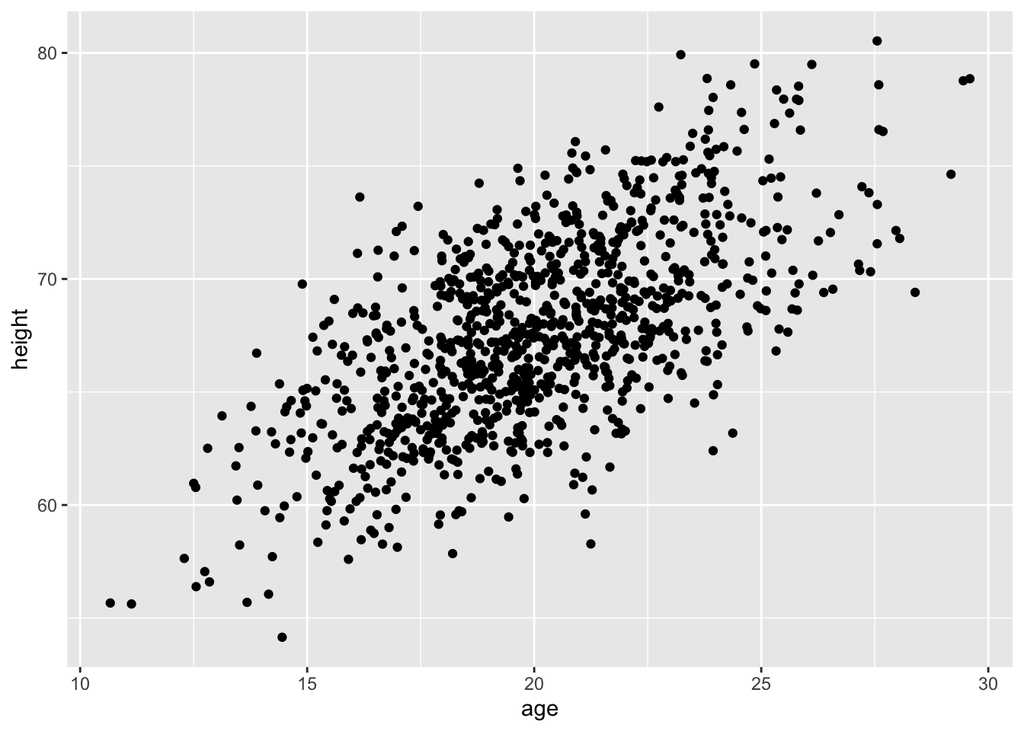

```r
f <- curl("https://raw.githubusercontent.com/fuzzyatelin/fuzzyatelin.github.io/master/AN588_Fall21/zombies.csv")

d <- read.csv(f, header = TRUE, sep = ",", stringsAsFactors = FALSE)
#creates data frame from raw csv file

AgeVsHeight <- ggplot(d, aes(x = age, y = height)) + geom_point()
AgeVsHeight
```

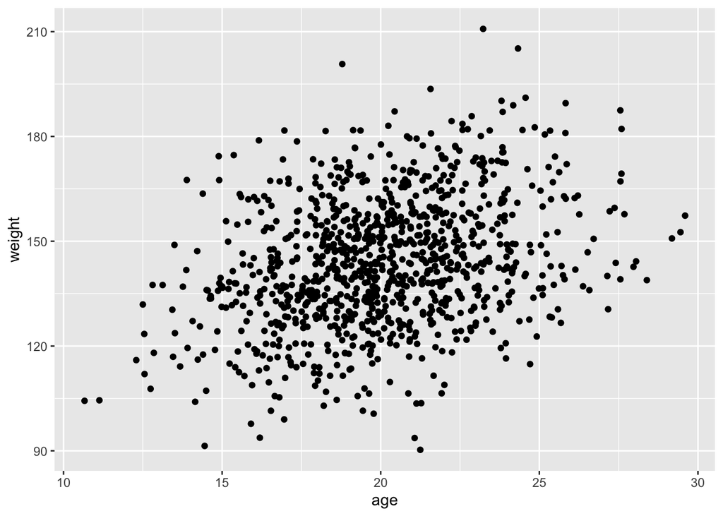

```r
#geom_point() is used to generate a scatter plot. With ggplot, you specify where the data is drawn from by using the ggplot function and then + ....() to specify how that data should be plotted.

AgeVsWeight <- ggplot(d, aes(x = age, y = weight)) + geom_point()
AgeVsWeight
```

There appears to be a positive correlation between age and height as well as between age and weight.

# Part Four

Using histograms and Q-Q plots, check whether the quantitative variables seem to be drawn from a normal distribution. Which seem to be and which do not (hint: not all are drawn from the normal distribution)? For those that are not normal, can you determine from which common distribution they are drawn?

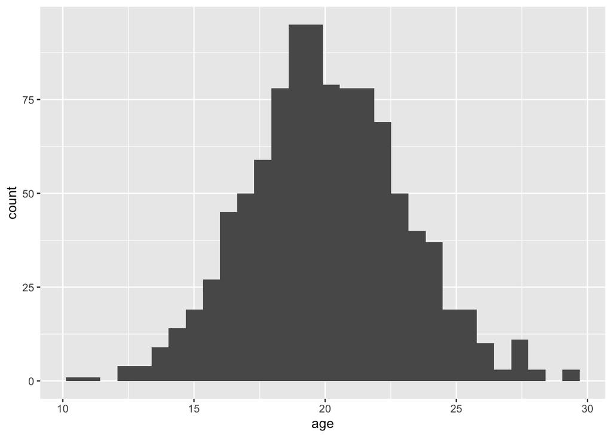

```r
f <- curl("https://raw.githubusercontent.com/fuzzyatelin/fuzzyatelin.github.io/master/AN588_Fall21/zombies.csv")

d <- read.csv(f, header = TRUE, sep = ",", stringsAsFactors = FALSE)
#creates data frame from raw csv file

s <- select(d, "height", "weight", "age", "zombies_killed", "years_of_education")

#c <- ggplot(mpg, aes(hwy)); c2 <- ggplot(mpg)
#use c for histogram, c2 for qq plot
#c + geom_histogram(binwidth = 5) x, y, alpha, color, fill, linetype, size, weigh
#c2 + geom_qq(aes(sample = hwy)) x, y, alpha, color, fill, linetype, size, weight


ggplot(s, aes(x = age)) + geom_histogram()
```

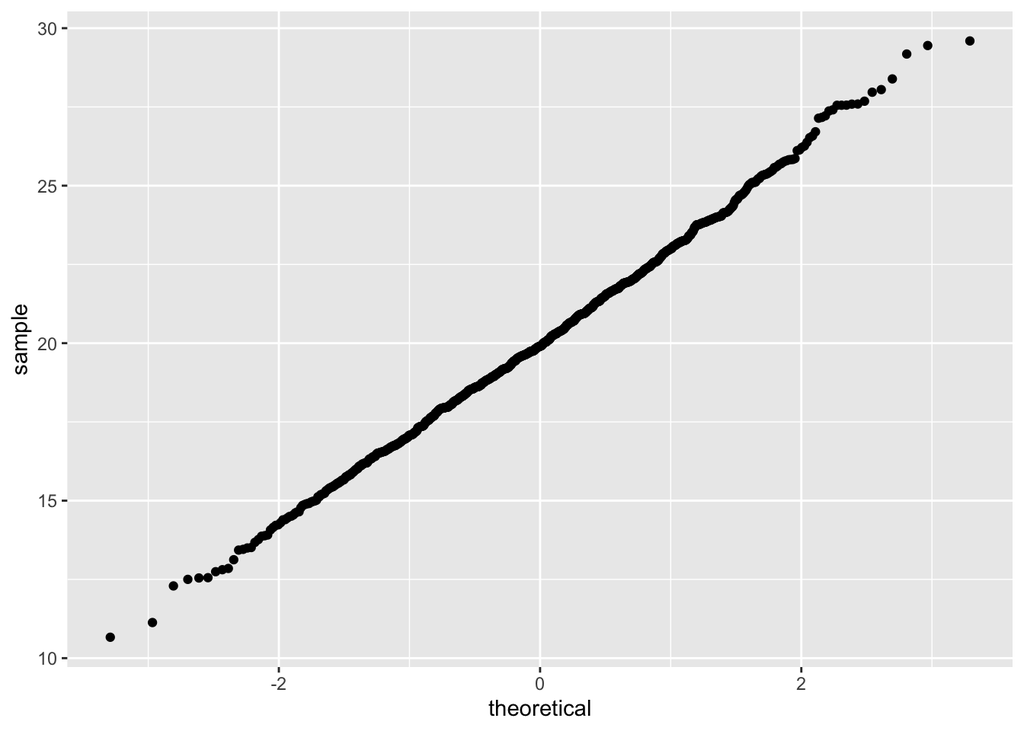

```r
ggplot(s, aes(sample = age)) + geom_qq()
```

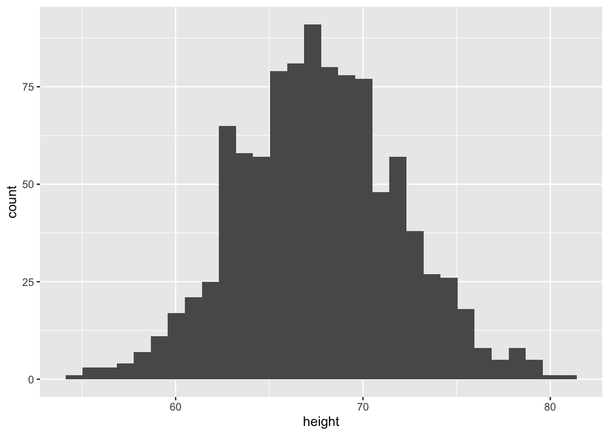

```r
#age

ggplot(s, aes(x = height)) + geom_histogram()
```

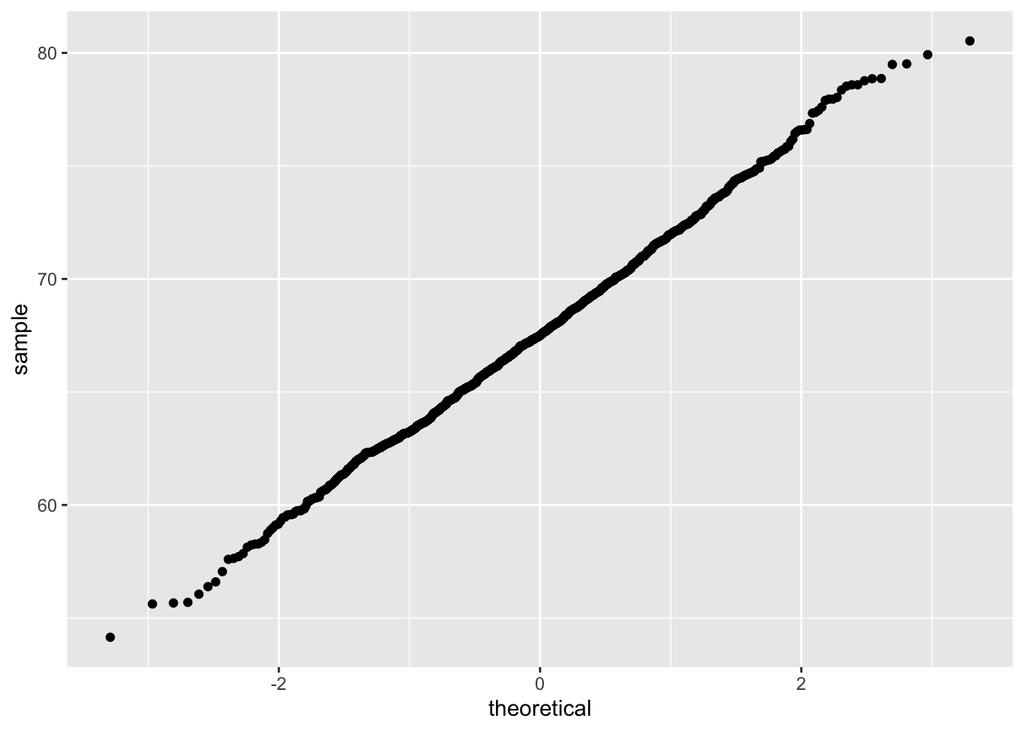

```r
ggplot(s, aes(sample = height)) + geom_qq()
```

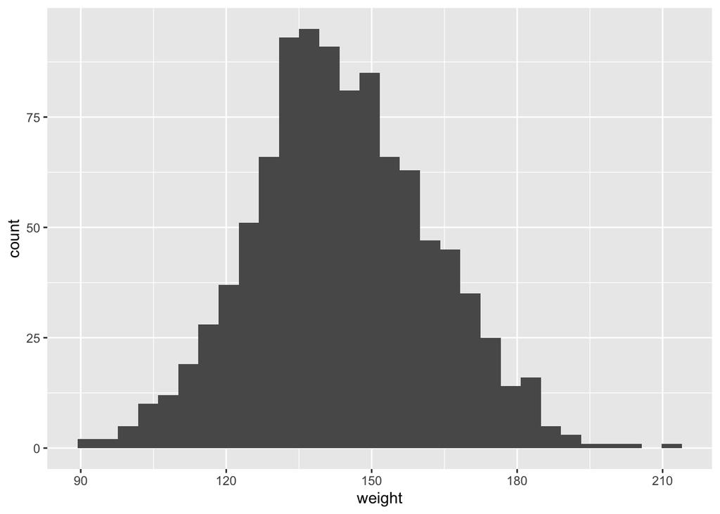

```r
#height

ggplot(s, aes(x = weight)) + geom_histogram()
```

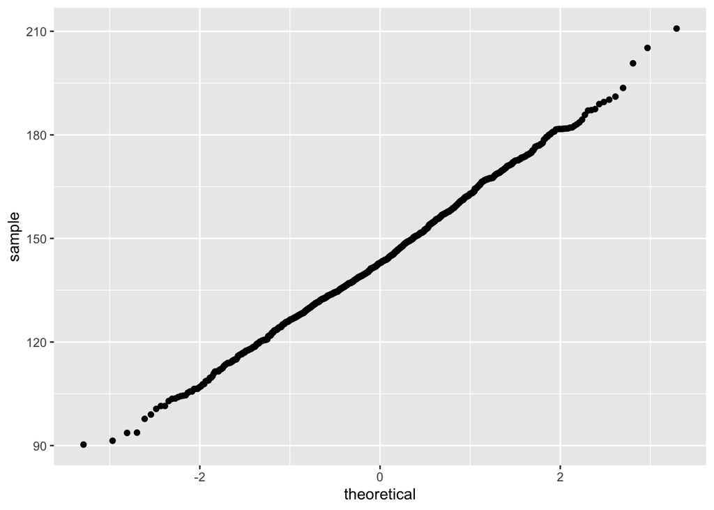

```r
ggplot(s, aes(sample = weight)) + geom_qq()
```

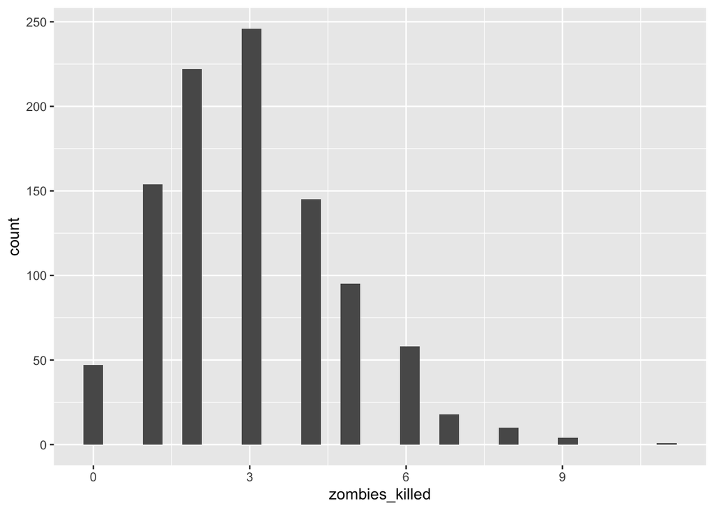

```r
#weight

ggplot(s, aes(x = zombies_killed)) + geom_histogram()
```

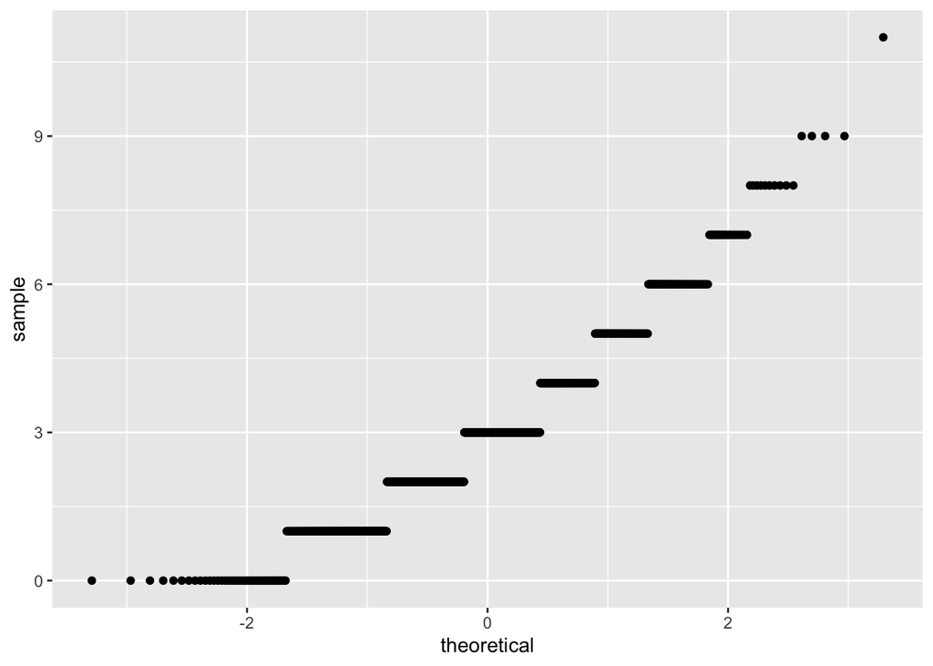

```r
ggplot(s, aes(sample = zombies_killed)) + geom_qq()
```

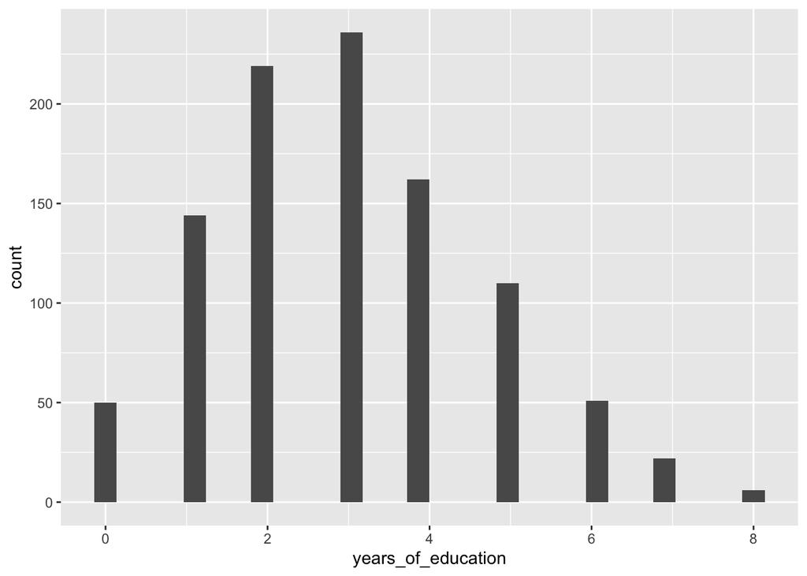

```r
#number of zombies killed

ggplot(s, aes(x = years_of_education)) + geom_histogram()
```

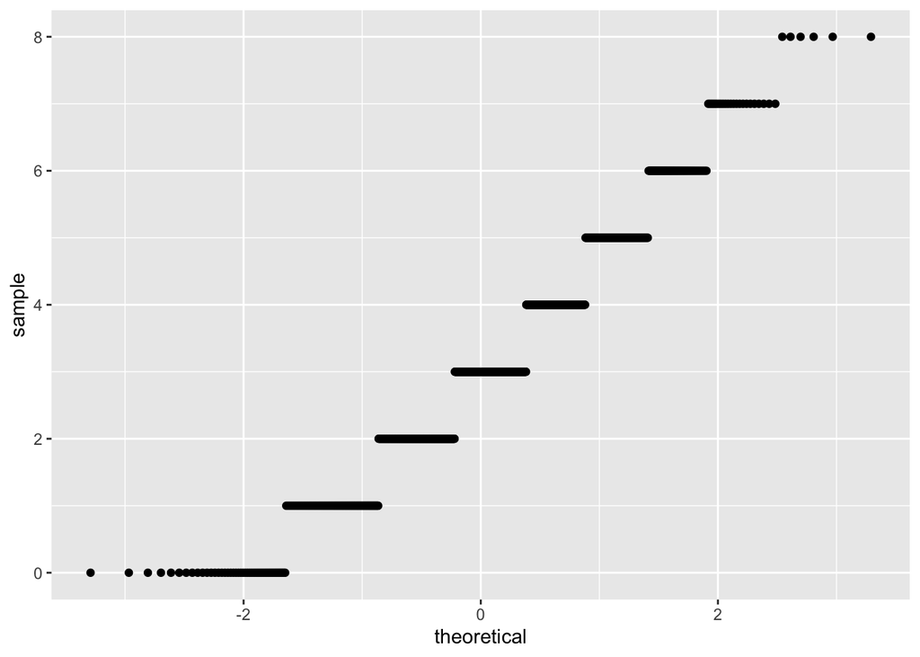

```r
ggplot(s, aes(sample=years_of_education)) + geom_qq()
```

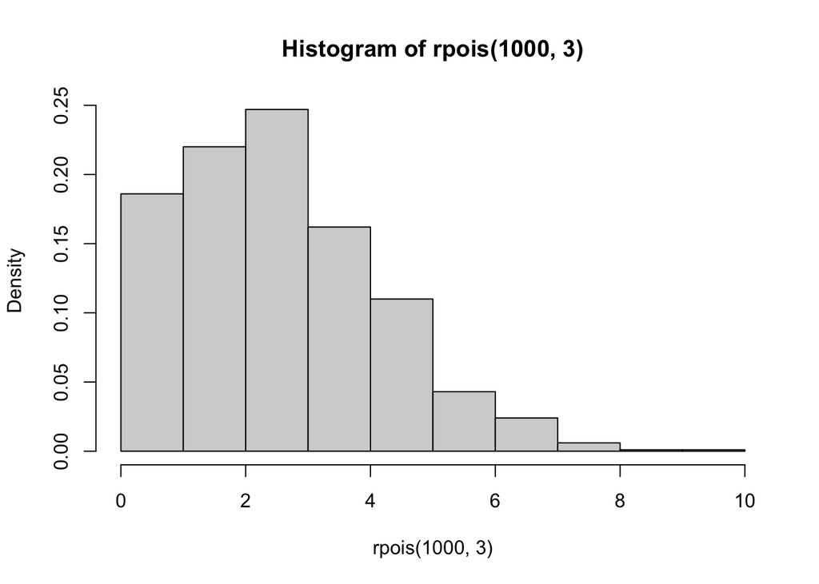

```r
#years of education

hist(rpois(1000, 3), probability = T)
```

```r
#distribution -- looks like Poisson
```

Age, height, and weight appear to be normally distributed. However, number of zombies killed and years of education appear to be skewed due to their curved qqplots and histograms which both appear to be somewhat skewed right.

Zombies killed and years of education appear to be drawn from the Poisson distribution, which makes sense since Poisson distributions are used to show the probability of an event occurring over a specific period of time.

# Part Five

Now use the sample() function to sample ONE subset of 30 zombie survivors (without replacement) from this population and calculate the mean and sample standard deviation for each variable. Also estimate the standard error for each variable, and construct the 95% confidence interval for each mean. Note that for the variables that are not drawn from the normal distribution, you may need to base your estimate of the CIs on slightly different code than for the normal…

package sciplot has standard error in it

```r
f <- curl("https://raw.githubusercontent.com/fuzzyatelin/fuzzyatelin.github.io/master/AN588_Fall21/zombies.csv")

d <- read.csv(f, header = TRUE, sep = ",", stringsAsFactors = FALSE)
#creates data frame from raw csv file

set.seed(30)
sample <- d[sample(nrow(d), 30, replace = FALSE), ]

s <- select(sample, "height", "weight", "age", "zombies_killed", "years_of_education")


#**Normally Distributed CI's:**

n <- select(sample, "height", "weight", "age")

nstat <- cbind(mean = apply(n, 2, mean),
               sd = apply(n, 2, pop_sd),
               se = (apply(n, 2, pop_sd))/sqrt(length(n)),
               lower = (apply(n, 2, mean)) - qnorm(1 - 0.05/2) * (apply(n, 2, pop_sd))/sqrt(length(n)),
               upper = (apply(n, 2, mean)) + qnorm(1 - 0.05/2) * (apply(n, 2, pop_sd))/sqrt(length(n)))
nstat
```

```
##             mean        sd        se     lower     upper
## height  67.00077  5.117727  2.954721  61.20962  72.79191
## weight 144.53039 19.477669 11.245438 122.48974 166.57104
## age     19.37349  3.269286  1.887523  15.67401  23.07296
```

```r
library(boot)

#**Abnormally Distributed CI's:**

a <- select(sample, "zombies_killed", "years_of_education")

#for zombies killed:

zkset <- NULL  # sets up a dummy variable to hold our 10000 simulations
n <- 30
for (i in 1:1000) {
    zkset[i] <- mean(sample(a$zombies_killed, n, replace = TRUE))
}

quantile(zkset, c(0.025, 0.975))
```

```
##     2.5%    97.5%
## 2.599167 3.966667
```

```r
#for years of education:
yeset <- NULL  # sets up a dummy variable to hold our 10000 simulations
n <- 30
for (i in 1:1000) {
    yeset[i] <- mean(sample(a$years_of_education, n, replace = TRUE))
}

quantile(yeset, c(0.025, 0.975))
```

```
##     2.5%    97.5%
## 2.466667 3.166667
```

**Normally Distributed Data Stats:** mean sd se lower upper height 67.00077 5.117727 2.954721 61.20962 72.79191 weight 144.53039 19.477669 11.245438 122.48974 166.57104 age 19.37349 3.269286 1.887523 15.67401 23.07296

**Non-normally Distributed Data Stats:** zombies killed: mean: 3.233333 sd: 2.028815 se: 0.359589 CI: (2.599167, 3.966667)

years of education: mean: 2.833333 sd: 0.9855275 se: 0.1752246 CI: (2.466667, 3.166667)

I used bootstrapping to calculate these intervals.

# Part Six

Now draw 99 more random samples of 30 zombie apocalypse survivors, and calculate the mean for each variable for each of these samples. Together with the first sample you drew, you now have a set of 100 means for each variable (each based on 30 observations), which constitutes a sampling distribution for each variable. What are the means and standard deviations of this distribution of means for each variable? How do the standard deviations of means compare to the standard errors estimated in [5]? What do these sampling distributions look like (a graph might help here)? Are they normally distributed? What about for those variables that you concluded were not originally drawn from a normal distribution?

```r
f <- curl("https://raw.githubusercontent.com/fuzzyatelin/fuzzyatelin.github.io/master/AN588_Fall21/zombies.csv")

d <- read.csv(f, header = TRUE, sep = ",", stringsAsFactors = FALSE)


set.seed(30)

#height:

height <- NULL

for(i in 1:100) {

  height[i] <- mean(sample(d$height, size=30, replace=FALSE, prob = NULL))

}

sheight <- height[]
sheight
```

```
##   [1] 67.00077 68.15250 66.96909 66.85753 67.27687 69.24747 67.51218 68.78230
##   [9] 68.20138 67.79102 67.30349 67.60165 67.91755 66.84382 67.39390 68.35016
##  [17] 68.16586 66.69135 67.00684 67.25698 67.94817 67.78515 68.89236 68.04810
##  [25] 67.06915 68.42903 68.13327 67.67233 67.61776 66.97868 67.78835 68.97019
##  [33] 67.63637 66.18307 67.14489 66.93362 67.29646 68.47626 68.01257 67.27190
##  [41] 67.43251 66.73578 67.79644 66.58073 66.80480 67.85758 68.21529 67.89165
##  [49] 67.71464 68.49018 67.25385 68.72819 68.04279 67.50679 68.79829 66.71732
##  [57] 66.59759 67.39978 66.60095 66.76113 67.53671 67.69588 67.30135 68.80508
##  [65] 66.93995 68.45836 67.25206 66.47417 68.07371 67.45548 67.73488 68.26239
##  [73] 68.70268 67.26817 67.50493 66.47277 68.07413 68.41526 68.08191 68.42063
##  [81] 66.56352 66.80830 67.83954 66.96020 67.62385 69.00959 68.83377 66.51156
##  [89] 67.51810 68.69056 67.98094 67.81601 68.01606 66.51871 67.94392 68.24629
##  [97] 68.46935 67.56590 67.99050 67.64236
```

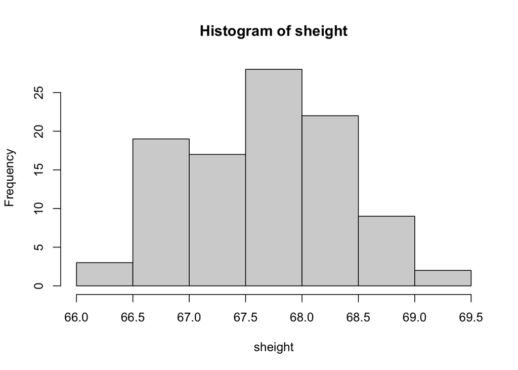

```r
hist(sheight)
```

```r
mean(sheight)
```

```
## [1] 67.66016
```

```r
sd(sheight)
```

```
## [1] 0.7026297
```

```r
#weight:

weight <- NULL

for(i in 1:100) {

  weight[i] <- mean(sample(d$weight, size=30, replace=FALSE, prob = NULL))

}

sweight <- weight[]
sweight
```

```
##   [1] 146.1097 152.5870 144.5445 143.8819 138.4849 146.2197 136.9023 143.6257
##   [9] 146.3001 148.2035 140.6977 146.6235 139.9947 143.0169 144.0937 142.4452
##  [17] 144.8857 142.6027 142.8487 145.1074 142.9955 146.5412 135.5491 143.0708
##  [25] 141.7484 147.1075 144.9481 145.3959 147.5519 146.8712 147.1982 141.6527
##  [33] 141.1372 145.5128 141.8474 141.2343 150.2903 150.8154 147.1424 144.0146
##  [41] 141.7615 150.2143 144.2007 142.2777 140.1600 147.2945 142.3787 145.8062
##  [49] 141.1266 149.1005 144.6156 145.8152 146.2408 142.0009 138.5078 142.5712
##  [57] 142.1207 142.7644 141.5323 148.8548 142.8882 142.3345 139.6416 147.2413
##  [65] 147.0626 139.7791 142.8884 143.1007 145.6684 142.6972 143.2580 138.0686
##  [73] 142.8113 145.6338 142.4537 139.9230 146.1516 146.1192 144.7175 146.9862
##  [81] 140.5457 142.8078 149.6750 143.9187 143.4665 143.0410 139.9267 143.3067
##  [89] 144.6726 144.2406 148.6417 143.4317 141.6924 144.0171 142.3458 145.1843
##  [97] 143.3975 139.0688 141.8139 147.2896
```

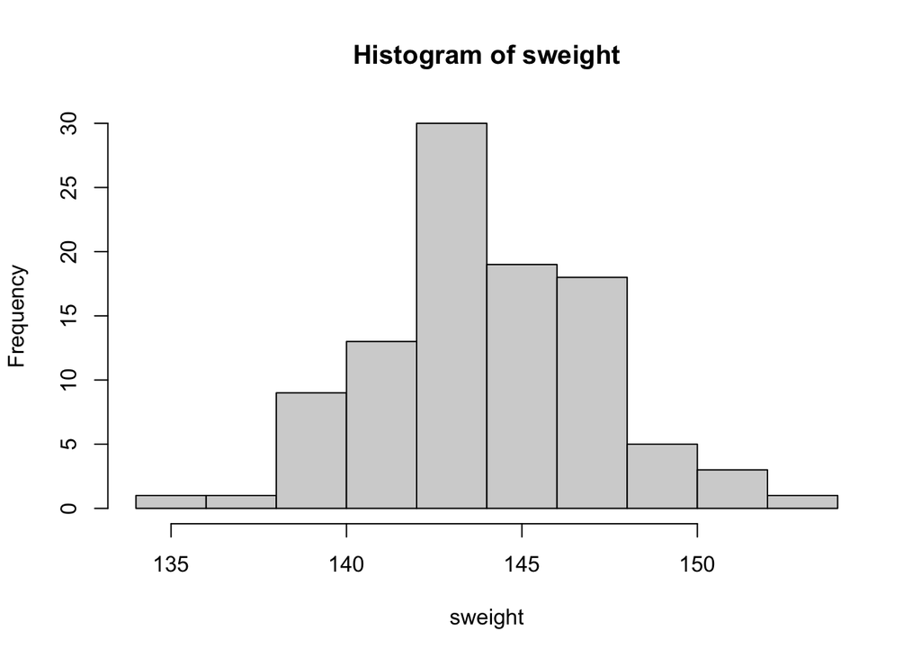

```r
hist(sweight)
```

```r
mean(sweight)
```

```
## [1] 143.9305
```

```r
sd(sweight)
```

```
## [1] 3.105085
```

```r
#age:

age <- NULL

for(i in 1:100) {

  age[i] <- mean(sample(d$age, size=30, replace=FALSE, prob = NULL))

}

sage <- age[]
sage
```

```
##   [1] 19.82031 19.88300 20.45782 21.16634 20.63773 20.60041 19.84205 19.80765
##   [9] 19.88014 19.30924 19.91294 20.39586 19.95329 20.43525 20.23218 19.63398
##  [17] 19.72434 20.44733 21.06006 19.80061 19.29788 20.25422 19.39468 20.29875
##  [25] 19.98370 20.41328 19.94000 19.37602 20.03129 19.96755 20.44712 20.58823
##  [33] 19.82937 19.79916 19.26104 20.01452 19.71448 21.01929 19.84111 20.41620
##  [41] 20.46160 19.52634 19.46523 20.29483 19.04228 20.03338 19.95644 20.10707
##  [49] 19.12770 19.25507 19.66756 20.51941 21.28771 19.71887 19.68249 20.68850
##  [57] 20.03141 19.90649 20.69086 20.90800 20.16456 20.27541 19.43303 20.45825
##  [65] 20.09421 19.50492 20.07061 19.53861 20.12060 20.31920 19.82798 19.80401
##  [73] 19.23741 20.26316 20.80861 19.93443 19.93935 20.58355 20.34942 19.53950
##  [81] 19.66686 19.34364 19.48685 19.77330 21.12101 19.97016 20.15316 20.55029
##  [89] 19.53551 20.27126 20.31404 19.75833 19.98853 19.51456 20.42616 20.07225
##  [97] 20.00399 20.66962 20.32228 19.87372
```

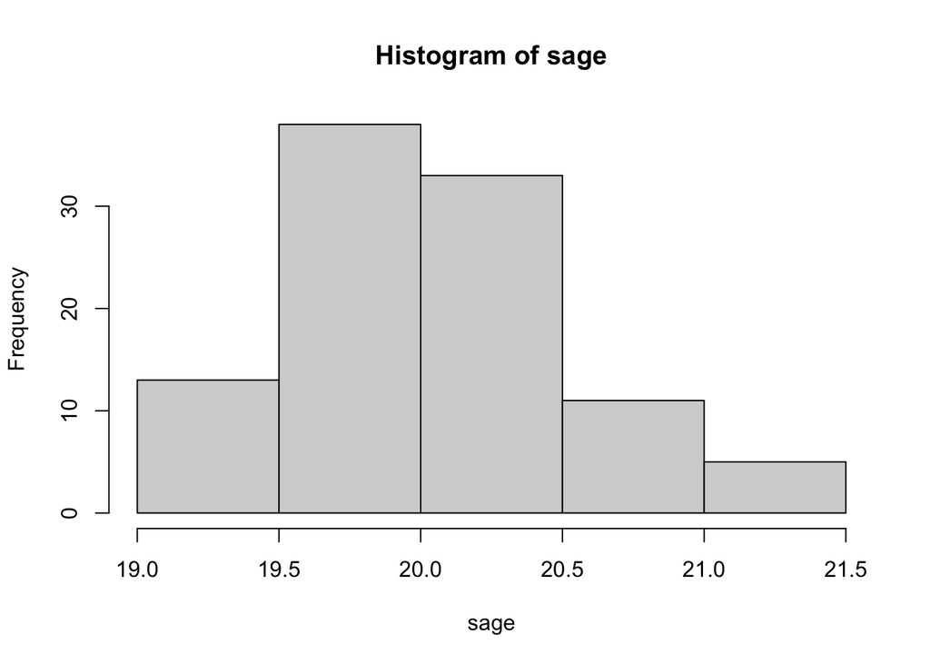

```r
hist(sage)
```

```r
mean(sage)
```

```
## [1] 20.04342
```

```r
sd(sage)
```

```
## [1] 0.4820888
```

```r
#zombies killed

zk <- NULL

for(i in 1:100) {

  zk[i] <- mean(sample(d$zombies_killed, size=30, replace=FALSE, prob = NULL))

}

szk <- zk[]
szk
```

```
##   [1] 2.866667 2.200000 3.066667 3.400000 3.166667 3.233333 3.333333 3.500000
##   [9] 2.566667 3.000000 3.133333 3.366667 3.266667 2.900000 3.233333 2.366667
##  [17] 3.366667 2.966667 3.166667 2.733333 2.566667 3.600000 3.400000 3.066667
##  [25] 3.166667 3.166667 2.933333 3.300000 3.533333 3.133333 2.633333 2.900000
##  [33] 2.900000 3.466667 3.266667 2.666667 3.033333 3.166667 3.000000 3.233333
##  [41] 2.800000 2.800000 2.866667 3.100000 2.733333 2.733333 2.633333 2.966667
##  [49] 3.033333 2.333333 3.100000 3.000000 2.833333 2.866667 2.800000 2.600000
##  [57] 2.733333 3.633333 2.700000 2.533333 3.066667 3.566667 2.866667 3.400000
##  [65] 2.833333 2.633333 3.633333 3.366667 2.366667 2.700000 3.166667 2.633333
##  [73] 3.000000 2.800000 2.100000 3.133333 3.466667 2.933333 2.833333 3.066667
##  [81] 2.766667 3.466667 3.366667 3.566667 3.133333 2.866667 3.100000 2.400000
##  [89] 3.000000 2.933333 2.966667 2.966667 3.033333 3.033333 3.000000 3.033333
##  [97] 2.966667 2.733333 3.200000 3.066667
```

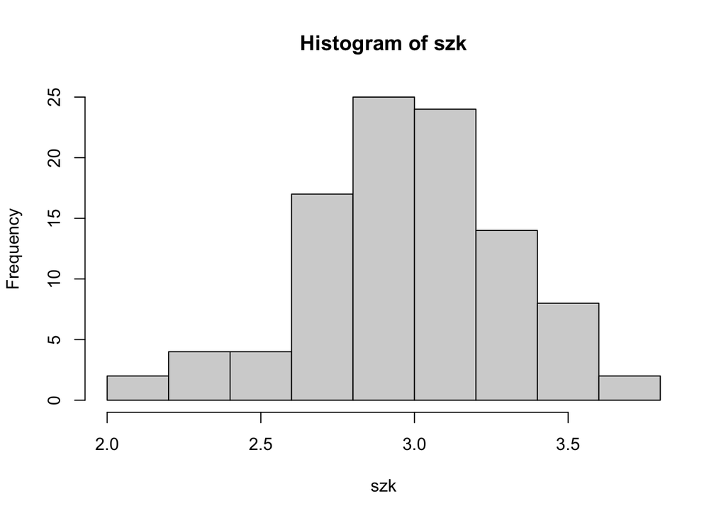

```r
hist(szk)
```

```r
mean(szk)
```

```
## [1] 2.999333
```

```r
sd(szk)
```

```
## [1] 0.3222738
```

```r
#years of education

ye <- NULL

for(i in 1:100) {

  ye[i] <- mean(sample(d$years_of_education, size=30, replace=FALSE, prob = NULL))

}

sye <- ye[]
sye
```

```
##   [1] 3.133333 2.633333 3.300000 2.733333 3.300000 2.933333 2.933333 3.000000
##   [9] 2.833333 2.900000 3.033333 2.566667 2.866667 2.333333 2.766667 3.133333
##  [17] 3.166667 2.866667 3.300000 3.333333 2.966667 2.766667 2.966667 2.966667
##  [25] 2.733333 2.866667 3.000000 3.166667 2.733333 3.133333 3.500000 2.500000
##  [33] 3.066667 2.500000 2.633333 2.800000 3.733333 2.766667 3.366667 3.366667
##  [41] 2.800000 2.866667 2.600000 2.800000 3.233333 3.266667 2.300000 2.833333
##  [49] 2.933333 2.800000 2.966667 2.766667 3.100000 3.300000 2.533333 3.333333
##  [57] 2.733333 2.766667 3.333333 2.666667 3.000000 3.333333 2.666667 3.566667
##  [65] 3.266667 2.500000 3.066667 2.800000 2.833333 2.666667 3.200000 3.000000
##  [73] 2.933333 2.700000 3.200000 3.133333 3.500000 2.866667 2.633333 3.000000
##  [81] 2.966667 3.000000 3.033333 3.033333 2.466667 2.933333 3.266667 3.100000
##  [89] 2.700000 2.800000 2.900000 3.166667 3.200000 2.733333 2.900000 2.766667
##  [97] 3.166667 3.066667 2.400000 3.266667
```

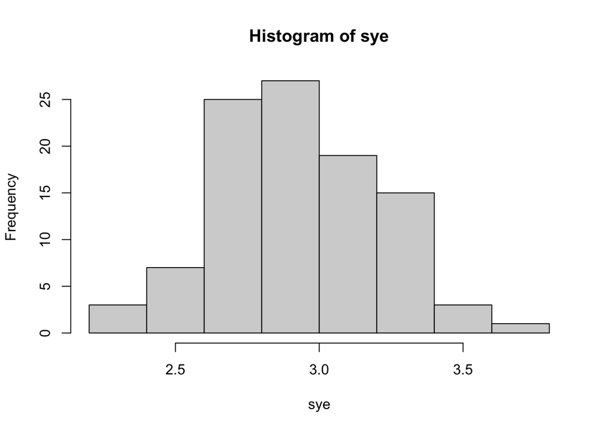

```r
hist(sye)
```

```r
mean(sye)
```

```
## [1] 2.952667
```

```r
sd(sye)
```

```
## [1] 0.2815772
```

The histograms look more normal, especially for the distributions that originally looked skewed.

Bootstrapping allows you to analyze non-normal data with parametric analysis.

# Challenges

1. I had trouble formatting functions to actually pull the data I wanted.
2. I could figure out how to get data one calculation at a time, but doing this more efficiently and getting data into nice data frames from scratch was tricky/not successful.
3. I had a lot of trouble figuring out how to use bootstrapping functions. I feel like this stemmed from a desire to use a function with “bootstrap” in the name that would just spit the answers out, which resulted in lots of difficulty with syntax and understanding what I was doing. When I just broke it down to the for loop, I had a much better idea of what bootstrapping even was. Obviously, this was in the modules, but I didn’t really understand it until I was doing it for the homework.